# Homework 07 Spring 2019 - ANSWER KEY

Melinda Higgins

April 12, 2019

## Homework 07 Spring 2019 - DUE April 17, 2019

## Course Material to Review

Recall the NHANES dataset that we used in Lesson 12 on March 27, 2019, https://htmlpreview.github.io/?https://github.com/vhertzb/ml_supervised/blob/master/ML_supervised.html. And more on supervised learning on April 10, 2019, https://htmlpreview.github.io/?https://github.com/vhertzb/more-supervised-learning/blob/master/More_Supervised_Learning.html.

Also review the logistic regression examples in Homework 6 assignment, see https://htmlpreview.github.io/?https://github.com/melindahiggins2000/N741_Homework06_regression/blob/master/homework6.html.

## Assignment

In the `NHANES` dataset there is a discrete variable called `Depressed` indicating whether each participant had “None”, “Several”, “Majority” or “AlmostAll” days in a month where the pariticpant felt down, depressed or hopeless. You are going to build a set of classifiers for this dependent variable. You may use any (set of) independent variable(s) you like except for the variable callsed `DaysMentHlthBad` (self-reported days that the participant’s mental health was not good out of 30 days).

Run this R code to get started and create 2 groups that either were depressed “None” versus more than “None” - the new variable is `depressedYes`.

```r
# load NHANES and dplyr packages
library(NHANES)
library(dplyr)

# add depressedYes to NHANES dataset
# ======================================
# TYPO - M. Higgins - Inside mutate
# you need to use an = and not the assign <- operator
# NHANES <- NHANES %>%
#   mutate(depressedYes <- Depressed != "None")
# ======================================
# CORRECTED
NHANES <- NHANES %>%
  mutate(depressedYes = Depressed != "None")

# check recoding that "Several" and "Most"
# are coded as TRUE for depressedYes
# and "None" are coded FALSE for depressedYes
NHANES %>%
  select(Depressed, depressedYes) %>%
  with(table(Depressed, depressedYes))
```

```
##          depressedYes
## Depressed FALSE TRUE
##   None     5246    0
##   Several     0 1009
##   Most        0  418
```

PROBLEM 1: Run 4 classifier models for `depressedYes`:

- logistic regression
- decision tree,
- random forest,
- k-nearest neighbor

For each model do the following:

1. Build the classifier.
2. Report its effectiveness on the NHANES dataset.
3. Make an appropriate visualization of this model.
4. Interpret the results. What have you learned about people who self-report being depressed?

NOTE: I (Melinda Higgins) created a subset with only a handful of potential variables as possibly associated with `depressedYes`. I used this subset for all of problem 1 below. Your variable choices will probably be different.

```r
nhdata <- NHANES %>%
  select(depressedYes, Age, Education, MaritalStatus,
         Poverty, BMI, HealthGen, SleepHrsNight,
         PhysActive)
```

## ANSWER KEY - LOGISTIC REGRESSION

### PROBLEM 1: ANSWER KEY Logistic Regression (A) Build Classifier

Run logistic regression model, use `summary()` function to view model results. And print odds ratios using `exp(coef())`.

```r
lrmod <- glm(depressedYes ~ ., data=nhdata, family=binomial)
summary(lrmod)
```

```
##
## Call:
## glm(formula = depressedYes ~ ., family = binomial, data = nhdata)
##
## Deviance Residuals:
##     Min       1Q   Median       3Q      Max
## -1.5562  -0.6995  -0.5271  -0.3486   2.5406
##
## Coefficients:
##                            Estimate Std. Error z value Pr(>|z|)
## (Intercept)               -0.648923   0.336503  -1.928  0.05380 .
## Age                       -0.001076   0.002490  -0.432  0.66566
## Education9 - 11th Grade    0.311555   0.166337   1.873  0.06106 .
## EducationHigh School       0.222267   0.159533   1.393  0.16355
## EducationSome College      0.220217   0.158745   1.387  0.16537
## EducationCollege Grad      0.257141   0.170088   1.512  0.13058
## MaritalStatusLivePartner  -0.040177   0.144545  -0.278  0.78105
## MaritalStatusMarried      -0.789017   0.107683  -7.327 2.35e-13 ***
## MaritalStatusNeverMarried -0.154917   0.125424  -1.235  0.21678
## MaritalStatusSeparated     0.230450   0.206758   1.115  0.26503
## MaritalStatusWidowed      -0.361807   0.165600  -2.185  0.02890 *
## Poverty                   -0.137812   0.024225  -5.689 1.28e-08 ***
## BMI                        0.001298   0.004935   0.263  0.79253
## HealthGenVgood             0.639170   0.150671   4.242 2.21e-05 ***
## HealthGenGood              0.904400   0.147846   6.117 9.52e-10 ***
## HealthGenFair              1.453102   0.161961   8.972  < 2e-16 ***
## HealthGenPoor              2.153666   0.228108   9.441  < 2e-16 ***
## SleepHrsNight             -0.124784   0.024306  -5.134 2.84e-07 ***
## PhysActiveYes             -0.197102   0.072729  -2.710  0.00673 **
## ---
## Signif. codes:  0 '***' 0.001 '**' 0.01 '*' 0.05 '.' 0.1 ' ' 1
##
## (Dispersion parameter for binomial family taken to be 1)
##
##     Null deviance: 6133.2  on 5960  degrees of freedom
## Residual deviance: 5602.4  on 5942  degrees of freedom
##   (4039 observations deleted due to missingness)
## AIC: 5640.4
##
## Number of Fisher Scoring iterations: 5
```

```r
exp(coef(lrmod))
```

```
##               (Intercept)                       Age
##                 0.5226082                 0.9989246
##   Education9 - 11th Grade      EducationHigh School
##                 1.3655475                 1.2489047
##     EducationSome College     EducationCollege Grad
##                 1.2463470                 1.2932278
##  MaritalStatusLivePartner      MaritalStatusMarried
##                 0.9606197                 0.4542913
## MaritalStatusNeverMarried    MaritalStatusSeparated
##                 0.8564866                 1.2591660
##      MaritalStatusWidowed                   Poverty
##                 0.6964170                 0.8712623
##                       BMI            HealthGenVgood
##                 1.0012989                 1.8949077
##             HealthGenGood             HealthGenFair
##                 2.4704495                 4.2763610
##             HealthGenPoor             SleepHrsNight
##                 8.6163865                 0.8826876
##             PhysActiveYes
##                 0.8211073
```

### PROBLEM 1: ANSWER KEY Logistic Regression (B) Effectiveness

One way to understand how well a logistic regression model did is to look at the “confusion matrix” or rather how many true and false positives and negatives were predicted - ideally all the classification should be perfect.

For this evaluation, I used a threhold of 0.5, which is a good place to start.

Original Numbers of Depressed and Not

```r
table(nhdata$depressedYes)
```

```
##
## FALSE  TRUE
##  5246  1427
```

Model predictions

```r
# look at the predicted probabilities
# review the help for predict.glm
lrmod.predict <- predict(lrmod, newdata=nhdata, type="response")
table(lrmod.predict > 0.50, nhdata$depressedYes)
```

```
##
##         FALSE TRUE
##   FALSE  4612 1141
##   TRUE     95  113
```

A better way is to compute the AUC - see the code below which computes the AUC and plots the curve to help “visualize” the model results.

### PROBLEM 1: ANSWER KEY Logistic Regression (C) Visualization of model

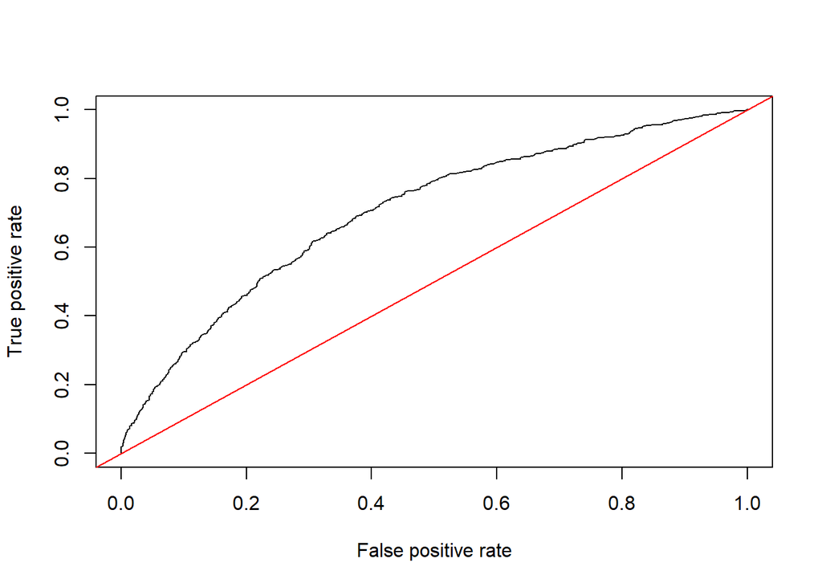

```r
# Note this code fails for missing data in outcomes
# and in the dataset, use this code to keep only complete cases

nhdata.complete <- na.omit(nhdata)

library(ROCR)
p <- predict(lrmod, newdata=nhdata.complete,
             type="response")
pr <- prediction(p, as.numeric(nhdata.complete$depressedYes))
prf <- performance(pr, measure = "tpr", x.measure = "fpr")
plot(prf)
abline(a=0, b=1, col="red")
```

```r
# the area under this curve compared
# to the y=x reference line
# tells you how well the model is predicting
# and AUC of 0.5 is a bad model - no better
# than flipping a coin
# AUC of 0.6-0.7 is still not very good
# AUC of 0.7-0.8 is pretty good
# AUC of 0.8-0.9 is good
# AUC 0.9-1.0 is great

auc <- performance(pr, measure = "auc")
auc <- auc@y.values[[1]]
auc
```

```
## [1] 0.7033142
```

### PROBLEM 1: ANSWER KEY Logistic Regression (D) Interpret Classifier

So, this model isn’t horrible, AUC = 0.7033142, but the model could be better - we should refine our variable selection and maybe include other predictors.

## ANSWER KEY - DECISION TREE

### PROBLEM 1: ANSWER KEY Decision Tree (A) Build Classifier

```r
library(rpart)
fitnh <- rpart(depressedYes ~ ., data=nhdata)
printcp(fitnh) # Display the results
```

```
##
## Regression tree:
## rpart(formula = depressedYes ~ ., data = nhdata)
##
## Variables actually used in tree construction:
## [1] HealthGen     MaritalStatus
##
## Root node error: 1121.8/6673 = 0.16812
##
## n=6673 (3327 observations deleted due to missingness)
##
##         CP nsplit rel error  xerror     xstd
## 1 0.038389      0   1.00000 1.00039 0.017094
## 2 0.019299      1   0.96161 0.96276 0.016865
## 3 0.010000      2   0.94231 0.94388 0.016367
```

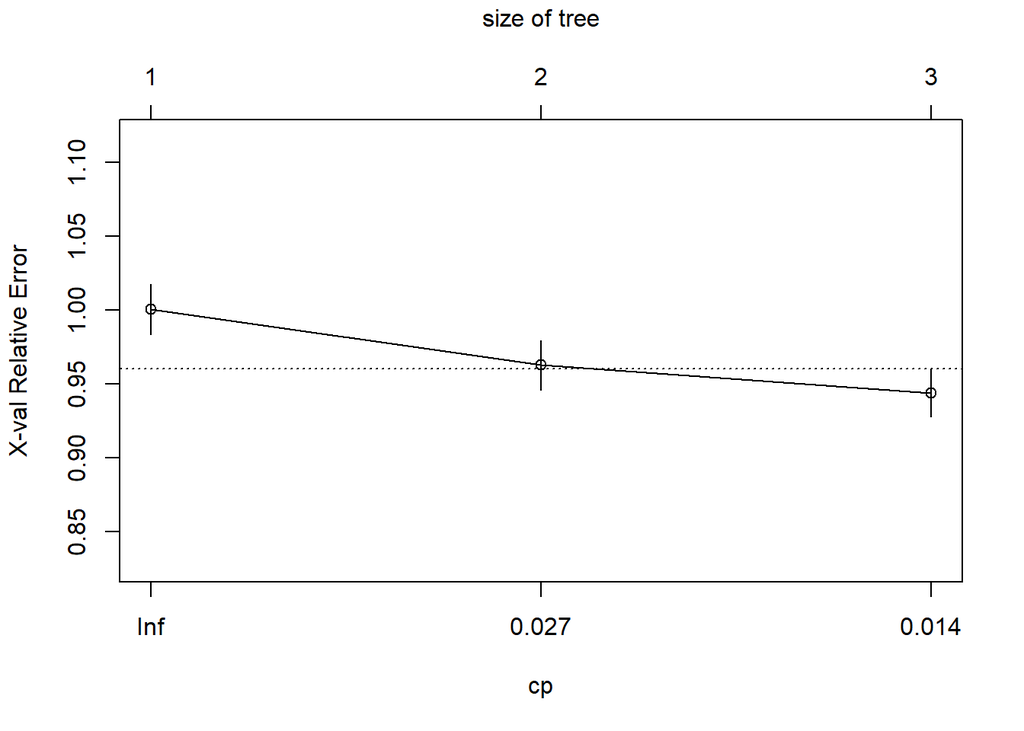

```r
plotcp(fitnh) # Visualize cross-validation results
```

```r
summary(fitnh) # Detailed summary of fit
```

```
## Call:
## rpart(formula = depressedYes ~ ., data = nhdata)
##   n=6673 (3327 observations deleted due to missingness)
##
##           CP nsplit rel error    xerror       xstd
## 1 0.03838925      0 1.0000000 1.0003905 0.01709360
## 2 0.01929903      1 0.9616108 0.9627561 0.01686451
## 3 0.01000000      2 0.9423117 0.9438828 0.01636735
##
## Variable importance
##     HealthGen MaritalStatus           Age       Poverty
##            60            31             8             1
##
## Node number 1: 6673 observations,    complexity param=0.03838925
##   mean=0.2138468, MSE=0.1681164
##   left son=2 (5563 obs) right son=3 (1110 obs)
##   Primary splits:
##       HealthGen     splits as  LLLRR,      improve=0.03838925, (0 missing)
##       Poverty       < 3.245  to the right, improve=0.02896423, (443 missing)
##       MaritalStatus splits as  RRLRRR,     improve=0.02472104, (236 missing)
##       SleepHrsNight < 4.5    to the right, improve=0.01920492, (13 missing)
##       PhysActive    splits as  RL,         improve=0.01174798, (0 missing)
##
## Node number 2: 5563 observations,    complexity param=0.01929903
##   mean=0.1779615, MSE=0.1462912
##   left son=4 (3280 obs) right son=5 (2283 obs)
##   Primary splits:
##       MaritalStatus splits as  RRLRRL,     improve=0.027756190, (215 missing)
##       Poverty       < 3.245  to the right, improve=0.019969520, (333 missing)
##       HealthGen     splits as  LLR--,      improve=0.012773470, (0 missing)
##       SleepHrsNight < 6.5    to the right, improve=0.012468210, (7 missing)
##       PhysActive    splits as  RL,         improve=0.005202115, (0 missing)
##   Surrogate splits:
##       Age           < 30.5   to the right, agree=0.709, adj=0.249, (215 split)
##       Poverty       < 0.985  to the right, agree=0.623, adj=0.026, (0 split)
##       BMI           < 18.925 to the right, agree=0.616, adj=0.008, (0 split)
##       SleepHrsNight < 3.5    to the right, agree=0.613, adj=0.000, (0 split)
##
## Node number 3: 1110 observations
##   mean=0.3936937, MSE=0.238699
##
## Node number 4: 3280 observations
##   mean=0.1259146, MSE=0.1100601
##
## Node number 5: 2283 observations
##   mean=0.2527376, MSE=0.1888613
```

### PROBLEM 1: ANSWER KEY Decision Tree (B) Effectiveness

In the `printcp()` output above, we can see that the `x error` for the final split was 0.94 which is still high, ideally we’d like to see this lower. It is noted that this tree only kept `HealthGen` and `MaritalStatus` in the model, so more variables are probably needed.

### PROBLEM 1: ANSWER KEY Decision Tree (C) Visualization of model

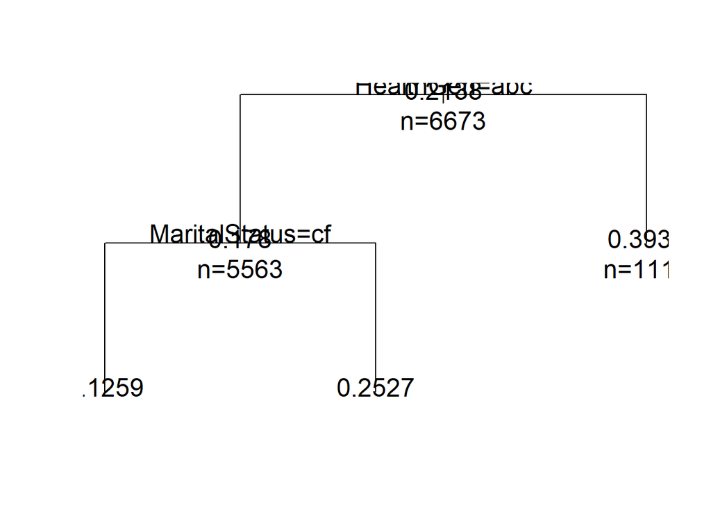

```r
# plot tree
plot(fitnh, uniform = TRUE, compress = FALSE)
text(fitnh, use.n = TRUE, all = TRUE, cex = 1.5)
```

### PROBLEM 1: ANSWER KEY Decision Tree (D) Interpret Classifier

Given the model only kept 2 variables and the x-error was still high, more variables will be needed to refine this classification tree further.

## ANSWER KEY - RANDOM FOREST

### PROBLEM 1: ANSWER KEY Random Forest (A) Build Classifier

```r
library(RColorBrewer)
library(plot3D)
library(parallel)
library(randomForestSRC)
library(ggRandomForests)

set.seed(131)
# Random Forest for the nhdata subset
# NOTE: The dataset must be a simple data.frame
# Add as.data.frame(nhdata) for this to work with rfsrc()
fitallrf <- rfsrc(depressedYes ~ .,
                  data = as.data.frame(nhdata),
                  ntree = 100, tree.err=TRUE)

# view the results
fitallrf
```

```
##                          Sample size: 5961
##                      Number of trees: 100
##            Forest terminal node size: 5
##        Average no. of terminal nodes: 579.48
## No. of variables tried at each split: 3
##               Total no. of variables: 8
##        Resampling used to grow trees: swr
##     Resample size used to grow trees: 5961
##                             Analysis: RF-R
##                               Family: regr
##                       Splitting rule: mse *random*
##        Number of random split points: 10
##                 % variance explained: 45.13
##                           Error rate: 0.09
```

### PROBLEM 1: ANSWER KEY Random Forest (B) Effectiveness

This isn’t too bad, the percent variance explained was 45.13 and the error rate was only 0.09.

### PROBLEM 1: ANSWER KEY Random Forest (C) Visualization of model

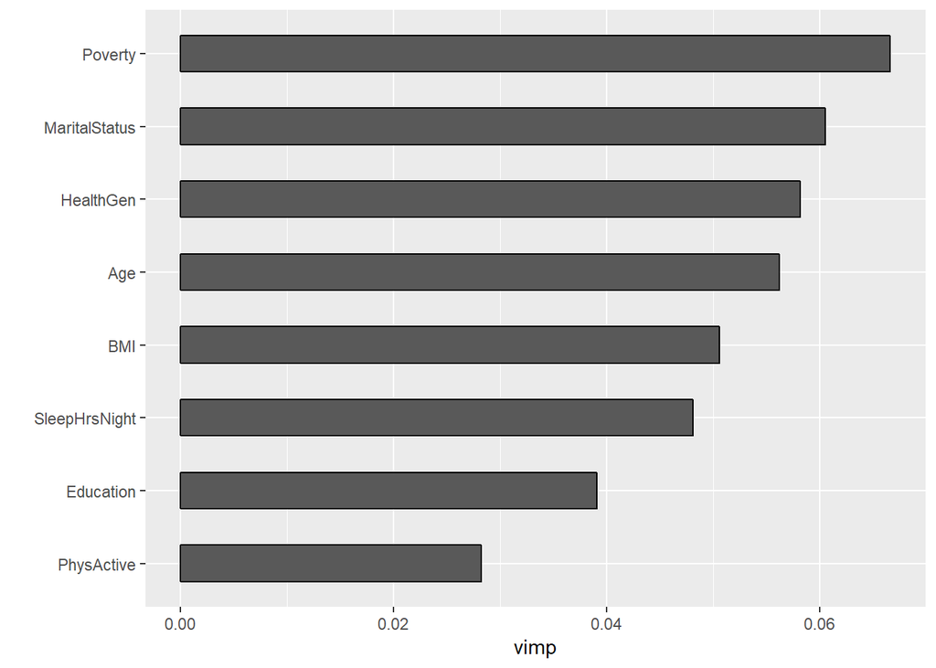

```r
# Plot the VIMP rankins of independent variables
plot(gg_vimp(fitallrf))
```

This plot shows us the relative importance of the predictors retained in the model, the top 3 are poverty, marital status and general health, followed by age, bmi, sleep, education and whether someone was physically active.

### PROBLEM 1: ANSWER KEY Random Forest (D) Interpret Classifier

The error rate was lower for the random forest than the classifcation and regression tree above and for the logistic regression.

Note: Dr. Hertzberg covered KNNs in her presentation https://htmlpreview.github.io/?https://github.com/vhertzb/more-supervised-learning/blob/master/More_Supervised_Learning.html.

## ANSWER KEY - K-NEAREST NEIGHBOR (KNN)

### PROBLEM 1: ANSWER KEY K-Nearest Neighbor (KNN) (A) Build Classifier

```r
library(class)

# no missing values allows, so use complete data as we fixed above
nhdata.complete <- na.omit(nhdata)

# and all factors have to be converted to
# numeric first for knn to work
nhdata.complete$Education <- as.numeric(nhdata.complete$Education)
nhdata.complete$MaritalStatus <- as.numeric(nhdata.complete$MaritalStatus)
nhdata.complete$HealthGen <- as.numeric(nhdata.complete$HealthGen)
nhdata.complete$PhysActive <- as.numeric(nhdata.complete$PhysActive)

# Apply knn procedure to predict depressedYes
# Let's try different values of k to see how that affects performance
knn.1 <- knn(train = nhdata.complete, test = nhdata.complete,
             cl = nhdata.complete$depressedYes, k = 1)

knn.3 <- knn(train = nhdata.complete, test = nhdata.complete,
             cl = nhdata.complete$depressedYes, k = 3)

knn.5 <- knn(train = nhdata.complete, test = nhdata.complete,
             cl = nhdata.complete$depressedYes, k = 5)

knn.20 <- knn(train = nhdata.complete, test = nhdata.complete,
              cl = nhdata.complete$depressedYes, k = 20)
```

### PROBLEM 1: ANSWER KEY K-Nearest Neighbor (KNN) (B) Effectiveness

```r
# Calculate the percent predicted correctly
100*sum(nhdata.complete$depressedYes == knn.1)/length(knn.1)
```

```
## [1] 100
```

```r
100*sum(nhdata.complete$depressedYes == knn.3)/length(knn.3)
```

```
## [1] 91.17598
```

```r
100*sum(nhdata.complete$depressedYes == knn.5)/length(knn.5)
```

```
## [1] 88.13957
```

```r
100*sum(nhdata.complete$depressedYes == knn.20)/length(knn.20)
```

```
## [1] 81.36219
```

The percentage declines with increasing neighbours considered.

Also consider success rates:

```r
# Another way to look at success rate against increasing k

table(knn.1, nhdata.complete$depressedYes)
```

```
##
## knn.1   FALSE TRUE
##   FALSE  4707    0
##   TRUE      0 1254
```

```r
table(knn.3, nhdata.complete$depressedYes)
```

```
##
## knn.3   FALSE TRUE
##   FALSE  4533  352
##   TRUE    174  902
```

```r
table(knn.5, nhdata.complete$depressedYes)
```

```
##
## knn.5   FALSE TRUE
##   FALSE  4535  535
##   TRUE    172  719
```

```r
table(knn.20, nhdata.complete$depressedYes)
```

```
##
## knn.20  FALSE TRUE
##   FALSE  4665 1069
##   TRUE     42  185
```

The KNN with k=1 did the best.

### PROBLEM 1: ANSWER KEY K-Nearest Neighbor (KNN) (C) Visualization of model

**SKIP** we didn’t cover this very well in class

### PROBLEM 1: ANSWER KEY K-Nearest Neighbor (KNN) (D) Interpret Classifier

The KNN with k=1 didn’t give any errors but it didn’t give us any insights either.

PROBLEM 2: Repeat problem 1 except now use the quantitative variable called `DaysMentHlthBad` as your outcome variable. Run 3 models:

- multiple linear regression,
- regression tree, and
- random forest.

And answer parts A, B, C, and D again for each model.

**NOTE: `depressedYes` and `DaysMentHlthBad` are correlated but were 2 separate questions and are not perfectly aligned. The amount of missing data `NA's` are different between the 2 variables.** To learn more about the variables in the dataset, run `help(NHANES, package = "NHANES")`.

## ANSWER KEY - MULTIPLE LINEAR REGRESSION

### PROBLEM 2: ANSWER KEY Multiple Linear Regression (A) Build Classifier *(well in this case the linear model, so building a “predictor” might be better verbiage)*

```r
# recreate dataset used above, but include DaysMentHlthBad
# instead of depressedYes
nhdata <- NHANES %>%
  select(DaysMentHlthBad, Age, Education, MaritalStatus,
         Poverty, BMI, HealthGen, SleepHrsNight,
         PhysActive)

lm1 <- lm(DaysMentHlthBad ~ ., data=nhdata)
summary(lm1)
```

```
##
## Call:
## lm(formula = DaysMentHlthBad ~ ., data = nhdata)
##
## Residuals:
##      Min       1Q   Median       3Q      Max
## -14.5703  -4.0800  -2.3622   0.4391  29.9120
##
## Coefficients:
##                            Estimate Std. Error t value Pr(>|t|)
## (Intercept)               10.524950   1.000641  10.518  < 2e-16 ***
## Age                       -0.036050   0.007182  -5.019 5.33e-07 ***
## Education9 - 11th Grade    1.610552   0.526728   3.058 0.002241 **
## EducationHigh School       0.771159   0.497846   1.549 0.121436
## EducationSome College      1.278063   0.493036   2.592 0.009559 **
## EducationCollege Grad      1.173910   0.518621   2.264 0.023639 *
## MaritalStatusLivePartner  -0.897114   0.481936  -1.861 0.062725 .
## MaritalStatusMarried      -0.853995   0.344188  -2.481 0.013122 *
## MaritalStatusNeverMarried -0.091390   0.409798  -0.223 0.823533
## MaritalStatusSeparated     0.478005   0.713866   0.670 0.503138
## MaritalStatusWidowed       0.466776   0.527517   0.885 0.376271
## Poverty                   -0.302322   0.071815  -4.210 2.59e-05 ***
## BMI                       -0.023173   0.015417  -1.503 0.132873
## HealthGenVgood             0.973984   0.338728   2.875 0.004049 **
## HealthGenGood              1.697924   0.341015   4.979 6.57e-07 ***
## HealthGenFair              3.750489   0.420762   8.914  < 2e-16 ***
## HealthGenPoor              8.082245   0.720661  11.215  < 2e-16 ***
## SleepHrsNight             -0.717221   0.074606  -9.613  < 2e-16 ***
## PhysActiveYes             -0.840186   0.216862  -3.874 0.000108 ***
## ---
## Signif. codes:  0 '***' 0.001 '**' 0.01 '*' 0.05 '.' 0.1 ' ' 1
##
## Residual standard error: 7.6 on 5963 degrees of freedom
##   (4018 observations deleted due to missingness)
## Multiple R-squared:  0.08382,    Adjusted R-squared:  0.08106
## F-statistic: 30.31 on 18 and 5963 DF,  p-value: < 2.2e-16
```

### PROBLEM 2: ANSWER KEY Multiple Linear Regression (B) Effectiveness

Given the variables I chose above, it looks like HealthGen is very significant and might even be sort of a proxy for the outcome. We may want to exclude this variable if it basically the same (theoretically) as the outcome `DaysMentHlthBad`.

That said, even with the significant predictors, the adjusted R2 of the whole is only 0.081, so 8.1%, which is pretty small - this is a small-to-moderate effect size *(approximately R2 = .02 is “small”, R2 = .09-12 is “moderate” and R2 = .25 is “large”)*, learn more by reading Cohen, Jacob (1988) Statistical Power Analysis for the Behavioral Sciences, Lawrence Erlbaum Associates, Hillsdale, New Jersey.

**Keep in mind that this dataset has over 5000+ subjects which is a large dataset, so this large sample size is also driving the smaller p-values. It is important to always evaluate effect sizes and theoretical relevance in addition to p-values and statistical significance.**

### PROBLEM 2: ANSWER KEY Multiple Linear Regression (C) Visualization of model

**Distribution of Outcome**

When evaluating how well a model does and how the diagnostic plots look, it is always good to keep in mind the distribution of the outcome variable which will influence all of these. This outcome `DaysMentHlthBad` is basically a “count” variable - these typically have an underlying *Poisson* or *Negative Binomial* distribution and not *Gaussian*/*Normal* distribution. However, the sample size is really large 5000+ which does allow the Centeral Limit Theorem to play a role in overcoming the non-normality of the distribution, so a linear regression model is ok here.

Although, when working with outcomes that truly come from a “count-based” data generating function, performing a Poisson or Negative Binomial regression would be better. Learn more about the `glm()` function with `family = poisson` from base `R` or the `glm.nb()` function for Negative Binomial from the `MASS` package. Learn more about Poisson Regression at https://stats.idre.ucla.edu/r/dae/poisson-regression/ and about Negative Binimial Regression at https://stats.idre.ucla.edu/r/dae/negative-binomial-regression/.

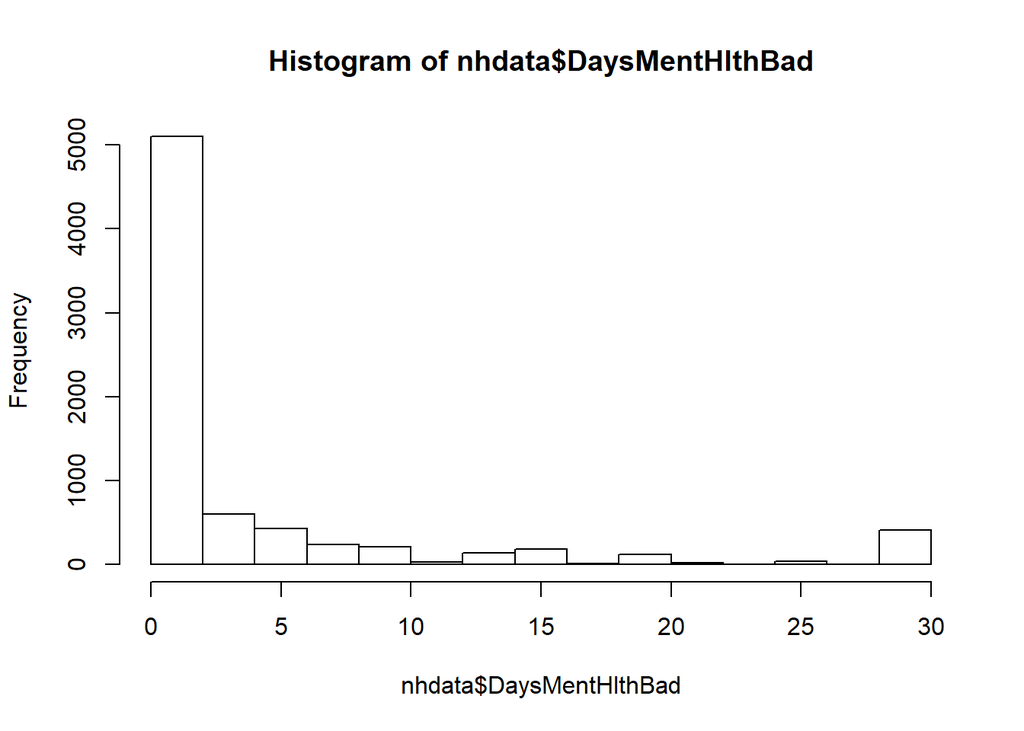

```r
hist(nhdata$DaysMentHlthBad)
```

**Model Plots**

Use the base `R` function `plot()` to get diagnostic plots of the model object `lm1`.

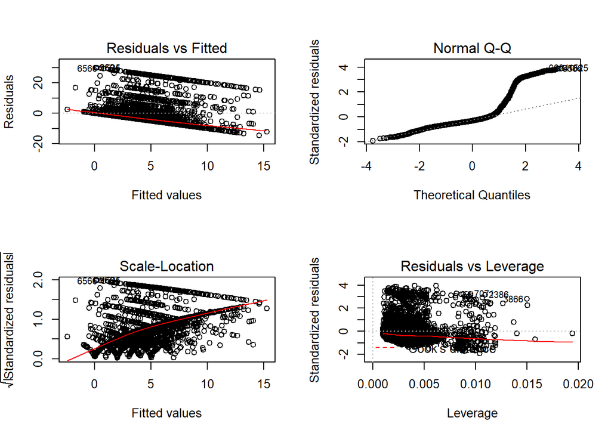

```r
par(mfrow=c(2,2))
plot(lm1)
```

```r
par(mfrow=c(1,1))
```

So, as you can see there is obvious skewness to these diagnostic plots.

**Residual Plots Using `car` Package functions**

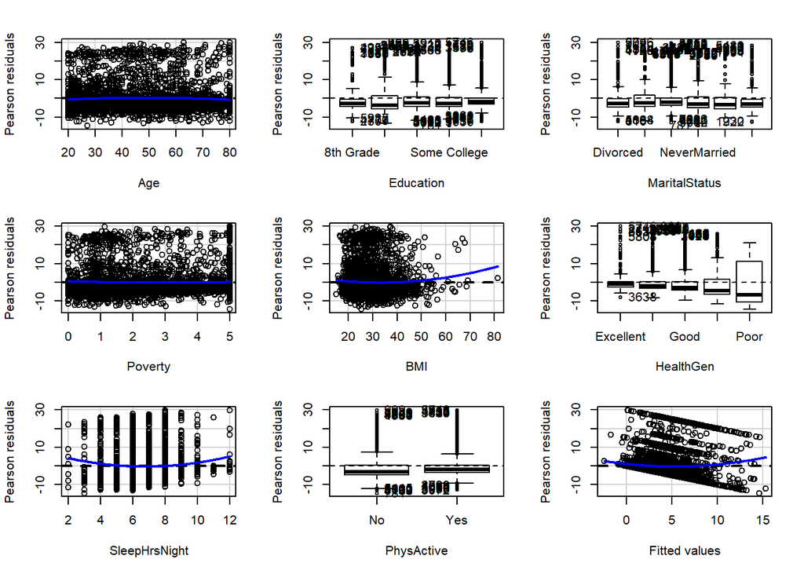

```
##               Test stat Pr(>|Test stat|)
## Age             -3.4393        0.0005873 ***
## Education
## MaritalStatus
## Poverty          1.5941        0.1109556
## BMI              3.3699        0.0007566 ***
## HealthGen
## SleepHrsNight    6.1923        6.326e-10 ***
## PhysActive
## Tukey test       6.5365        6.298e-11 ***
## ---
## Signif. codes:  0 '***' 0.001 '**' 0.01 '*' 0.05 '.' 0.1 ' ' 1
```

```r
library(car)

#get the residual plots
residualPlots(lm1)
```

**Residuals versus Predicted**

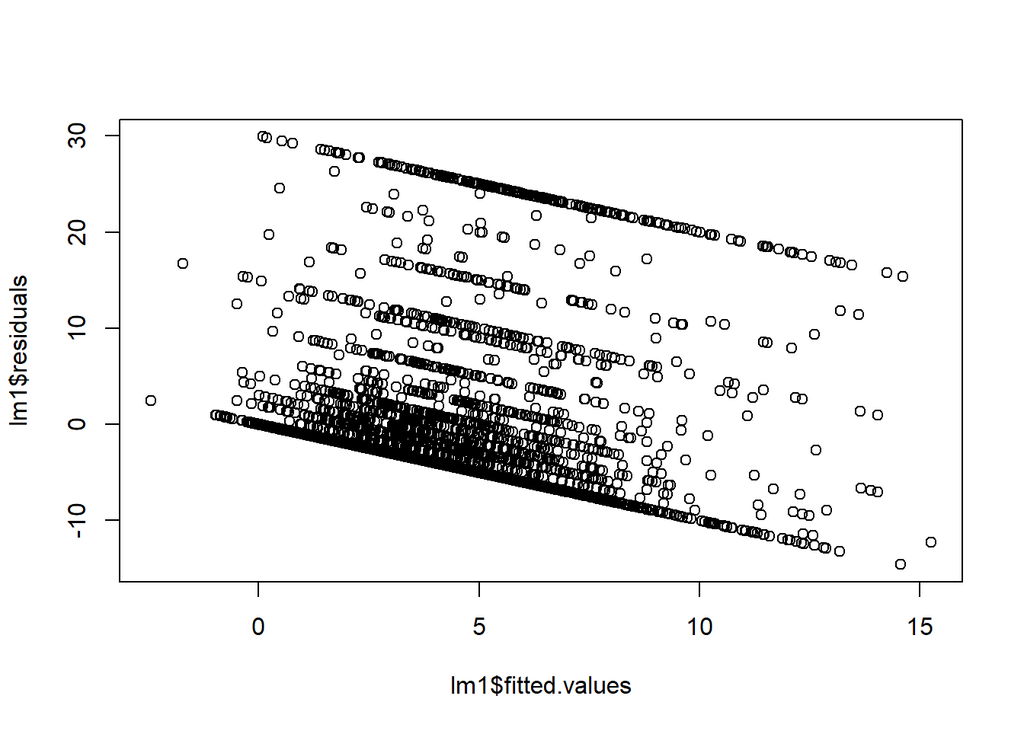

```r
plot(lm1$fitted.values, lm1$residuals)
```

**QQ-Plot of Residuals**

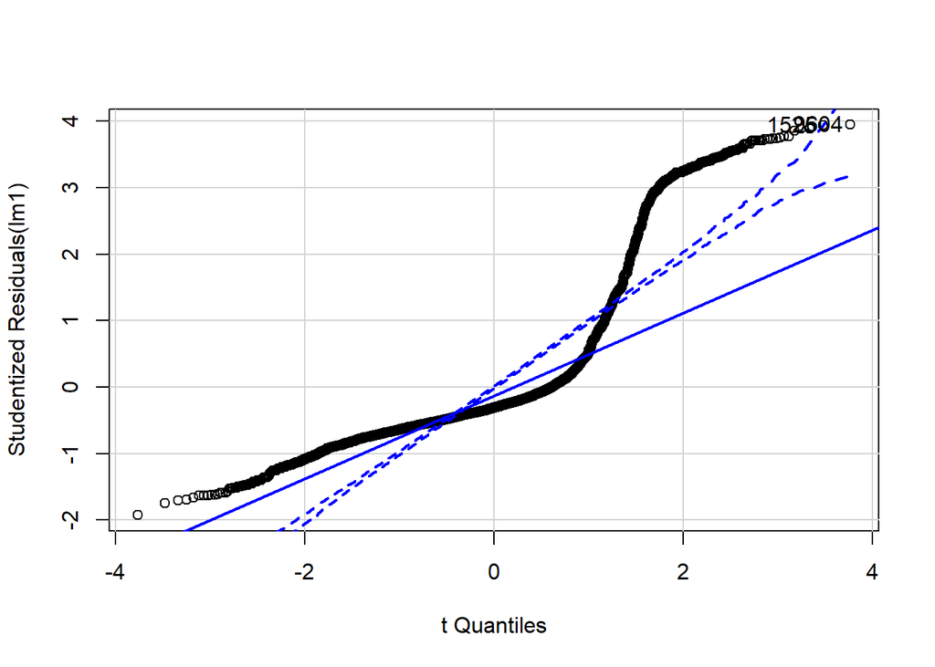

```
## [1] 1525 9604
```

```r
car::qqPlot(lm1)
```

### PROBLEM 2: ANSWER KEY Multiple Linear Regression (D) Interpret Classifier

So, given these variables chosen here, the model is a poor predictor of the number of mental health bad since the R2 was pretty small. Also, the choice of a linear regression model, which assume a normally distributed outcome, is also not the best. A Poisson or Negative Binomial regression approach would be better.

## ANSWER KEY - REGRESSION TREE

It is worth noting that regression trees while not strictly linear still assumes a normally distributed outcome. Again the sample size helps with assumptions of the Central Limit Theorem, but admittedly the underlying outcome is a count-based variable.

### PROBLEM 2: ANSWER KEY Regression Tree (A) Build Classifier

**Build Model**

```r
library(rpart)
rtree1 <- rpart(DaysMentHlthBad ~ ., data=nhdata)
```

### PROBLEM 2: ANSWER KEY Regression Tree (B) Effectiveness

**View results**

```r
rtree1
```

```
## n=7534 (2466 observations deleted due to missingness)
##
## node), split, n, deviance, yval
##       * denotes terminal node
##
## 1) root 7534 462190.50 4.126493
##   2) HealthGen=Excellent,Vgood,Good 6341 311775.70 3.515849
##     4) SleepHrsNight>=4.5 6140 280853.20 3.333713 *
##     5) SleepHrsNight< 4.5 201  24496.73 9.079602 *
##   3) HealthGen=Fair,Poor 1193 135482.80 7.372171 *
```

```r
printcp(rtree1)
```

```
##
## Regression tree:
## rpart(formula = DaysMentHlthBad ~ ., data = nhdata)
##
## Variables actually used in tree construction:
## [1] HealthGen     SleepHrsNight
##
## Root node error: 462190/7534 = 61.347
##
## n=7534 (2466 observations deleted due to missingness)
##
##         CP nsplit rel error  xerror     xstd
## 1 0.032307      0   1.00000 1.00015 0.029199
## 2 0.013903      1   0.96769 0.97035 0.027804
## 3 0.010000      2   0.95379 0.96081 0.027380
```

Notice that only `HealthGen` and `SleepHrsNight` are used in this regression tree model.

### PROBLEM 2: ANSWER KEY Regression Tree (C) Visualization of model

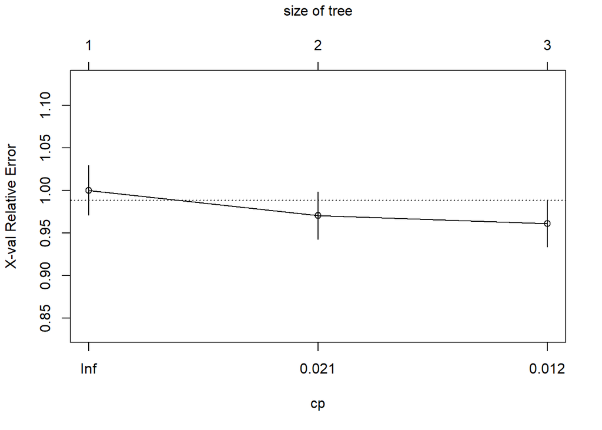

```r
plotcp(rtree1)
```

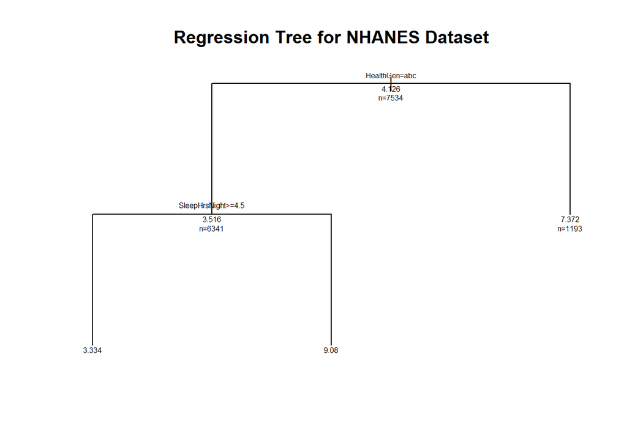

```r
plot(rtree1, uniform = TRUE, compress = FALSE,
     main = "Regression Tree for NHANES Dataset")
text(rtree1, use.n = TRUE, all = TRUE, cex = 0.5)
```

### PROBLEM 2: ANSWER KEY Regression Tree (D) Interpret Classifier

**EXTRA TIDBIT ON NON-PARAMETRIC REGRESSION TREES**

[figure not shown]

```r
# NOTE: data must be complete, no missing data allowed.
nhdata.complete <- na.omit(nhdata)

library(party)
ctree1 <- ctree(DaysMentHlthBad ~ ., data=nhdata.complete)
plot(ctree1, main = "Conditional Inference Tree for Days Mental Health Bad")
```

At first glance, this non-parametric approach regression tree model seems better - it includes many more variables in the model.

## ANSWER KEY - RANDOM FOREST

### PROBLEM 2: ANSWER KEY Random Forest (A) Build Classifier

```r
library(randomForestSRC)
set.seed(131)
# Random Forest
fitrf <- rfsrc(DaysMentHlthBad ~ .,
               data=as.data.frame(nhdata.complete),
               ntree = 100, tree.err=TRUE)

# view the results
fitrf
```

```
##                          Sample size: 5982
##                      Number of trees: 100
##            Forest terminal node size: 5
##        Average no. of terminal nodes: 937.13
## No. of variables tried at each split: 3
##               Total no. of variables: 8
##        Resampling used to grow trees: swr
##     Resample size used to grow trees: 5982
##                             Analysis: RF-R
##                               Family: regr
##                       Splitting rule: mse *random*
##        Number of random split points: 10
##                 % variance explained: 46.45
##                           Error rate: 33.66
```

### PROBLEM 2: ANSWER KEY Random Forest (B) Effectiveness

This model did pretty well, the error rate was only about 33-34% and the variance explained is much better than the linear regression model - the random forest explained 46.45%.

### PROBLEM 2: ANSWER KEY Random Forest (C) Visualization of model

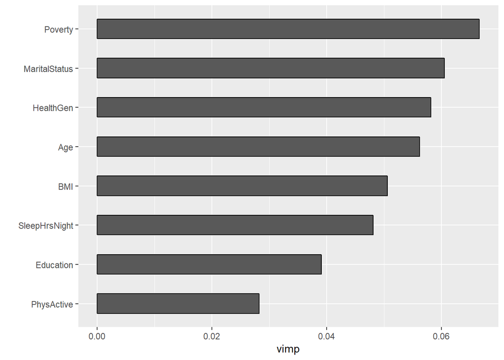

```r
library(ggRandomForests)

# Plot the VIMP rankins of independent variables
plot(gg_vimp(fitallrf))
```

### PROBLEM 2: ANSWER KEY Random Forest (D) Interpret Classifier

The random forest approach does do better than the linear model and the usual `rpart()` regression tree. The non-parametric `ctree()` did better and the random forest did better still.